# Similarity and Cinderella Teams

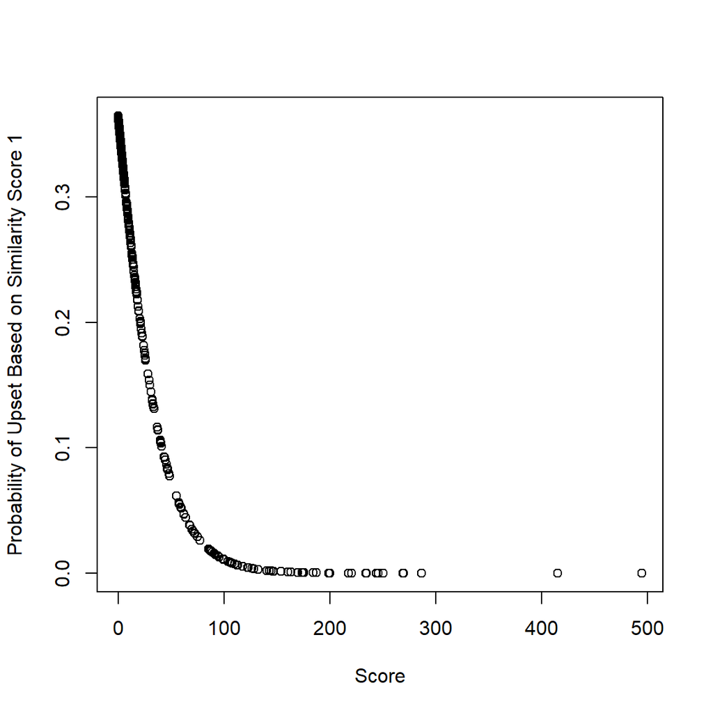

Figure: Plot of Score Vs. Probability of Upset.

```r
out = predict(mod2,newdata = train2)
plot(train2$Score1,out$data$prob.1,xlab="Score",ylab="Probability of Upset Based on Similarity Score 1")
```

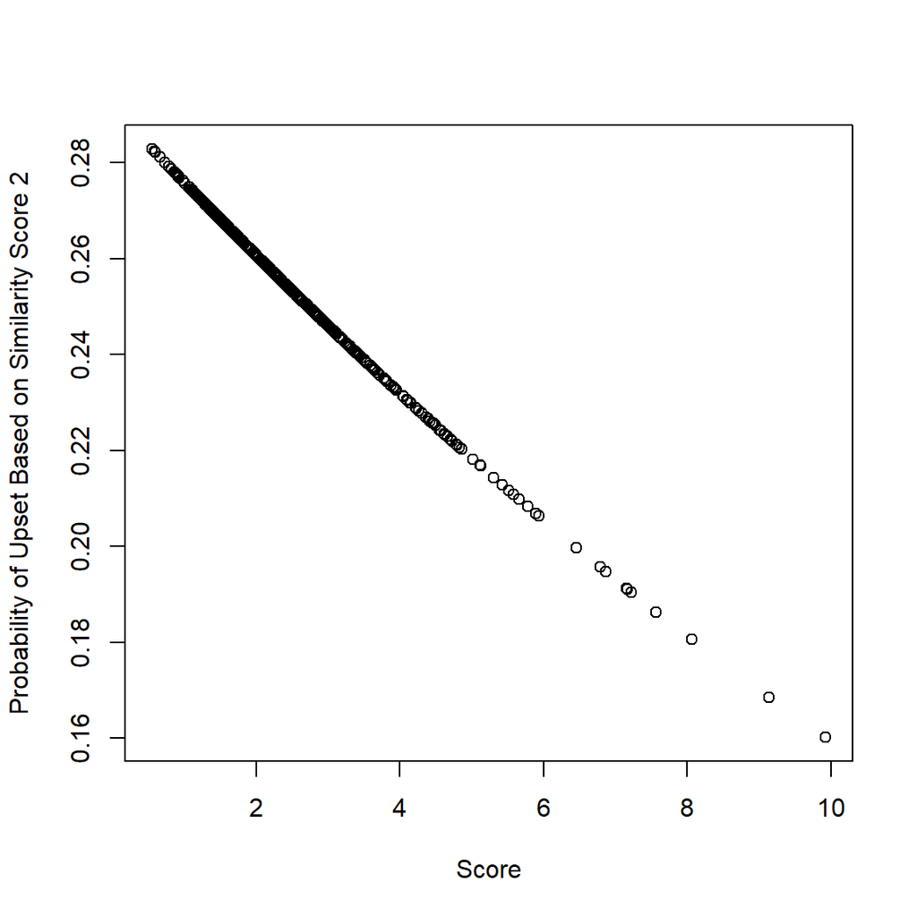

Figure: Plot of Score Vs. Probability of Upset.

```r
out = predict(mod3,newdata = train3)
plot(train3$Score2,out$data$prob.1,xlab="Score",ylab="Probability of Upset Based on Similarity Score 2")
```

## 2.4 Results and Performance

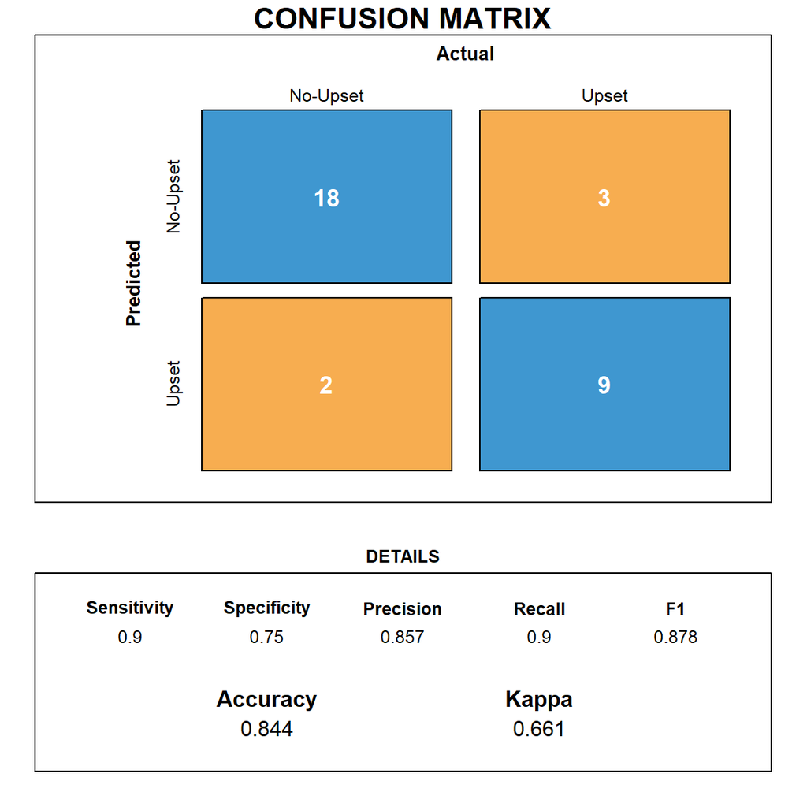

Confusion Matrix for 2019 tournament outcome

```r
cm <- caret::confusionMatrix(data = factor(resp), reference = factor(test3$Winner))
draw_confusion_matrix <- function(cm) {

  layout(matrix(c(1,1,2)))
  par(mar=c(2,2,2,2))
  plot(c(100, 345), c(300, 450), type = "n", xlab="", ylab="", xaxt='n', yaxt='n')
  title('CONFUSION MATRIX', cex.main=2)

  # create the matrix
  rect(150, 430, 240, 370, col='#3F97D0')
  text(195, 435, 'No-Upset', cex=1.2)
  rect(250, 430, 340, 370, col='#F7AD50')
  text(295, 435, 'Upset', cex=1.2)
  text(125, 370, 'Predicted', cex=1.3, srt=90, font=2)
  text(245, 450, 'Actual', cex=1.3, font=2)
  rect(150, 305, 240, 365, col='#F7AD50')
  rect(250, 305, 340, 365, col='#3F97D0')
  text(140, 400, 'No-Upset', cex=1.2, srt=90)
  text(140, 335, 'Upset', cex=1.2, srt=90)

  # add in the cm results
  res <- as.numeric(cm$table)
  text(195, 400, res[1], cex=1.6, font=2, col='white')
  text(195, 335, res[2], cex=1.6, font=2, col='white')
  text(295, 400, res[3], cex=1.6, font=2, col='white')
  text(295, 335, res[4], cex=1.6, font=2, col='white')

  # add in the specifics
  plot(c(100, 0), c(100, 0), type = "n", xlab="", ylab="", main = "DETAILS", xaxt='n', yaxt='n')
  text(10, 85, names(cm$byClass[1]), cex=1.2, font=2)
  text(10, 70, round(as.numeric(cm$byClass[1]), 3), cex=1.2)
  text(30, 85, names(cm$byClass[2]), cex=1.2, font=2)
  text(30, 70, round(as.numeric(cm$byClass[2]), 3), cex=1.2)
  text(50, 85, names(cm$byClass[5]), cex=1.2, font=2)
  text(50, 70, round(as.numeric(cm$byClass[5]), 3), cex=1.2)
  text(70, 85, names(cm$byClass[6]), cex=1.2, font=2)
  text(70, 70, round(as.numeric(cm$byClass[6]), 3), cex=1.2)
  text(90, 85, names(cm$byClass[7]), cex=1.2, font=2)
  text(90, 70, round(as.numeric(cm$byClass[7]), 3), cex=1.2)

  # add in the accuracy information
  text(30, 35, names(cm$overall[1]), cex=1.5, font=2)
  text(30, 20, round(as.numeric(cm$overall[1]), 3), cex=1.4)
  text(70, 35, names(cm$overall[2]), cex=1.5, font=2)
  text(70, 20, round(as.numeric(cm$overall[2]), 3), cex=1.4)
}
draw_confusion_matrix(cm)
```

```r
perf = do.call(rbind, perf)
perf  %>% head(10) %>% DT::datatable()
```

|  | Season | f1 | auc | precision | recall |
| --- | --- | --- | --- | --- | --- |
| 1 | 2016 | 0.67 | 0.77 | 0.64 | 0.69 |
| 2 | 2017 | 0.62 | 0.92 | 0.5 | 0.83 |
| 3 | 2018 | 0.64 | 0.74 | 0.54 | 0.78 |
| 4 | 2019 | 0.78 | 0.89 | 0.82 | 0.75 |

# 3 Conclusion

Based on the model results we can conclude that the similarity based approach can be used in identifying teams that are more likely to pull off an upset. The advantage of this approach is that it looks at the local trends in the data to identify similar teams. Given that it is hard to quantify underdog success using offensive or defensive stats because those stats are not unique to success of cinderella teams but to success of all teams in general.The resulting model has a good performance based on back-testing resultw.

# 4 Acknowledgements

Thanks to [Jason](https://www.kaggle.com/jaseziv83/moreyball-in-the-college-game-a-full-ncaa-eda/) for creating an awesome notebook. I used some of his codes for plotting.